# 利用常用分类算法对 Titanic 数据进行分类预测

Zhefeng Wang

May 27, 2015

# **[Kaggle Contest: Predicting Survival on the Titanic](https://www.kaggle.com/c/titanic)**

# **Content:**

**1.问题描述及理解**

**2.数据描述及理解**

**3.模型的选择及模型对数据的要求(模型假设)**

- **LDA QDA**
- **Logistic Regression**
- **KNN**
- **C4.5**
- **CART**
- **SVM**
- **Naive Bayes**
- **Bagging**
- **AdaBoost**
- **GBM**
- **Xgboost**
- **Random Forest**
- **EM**
- **Kmeans**
- **Apriori**
- **PageRank**
- …

**4.根据模型的限制对数据进行预处理**

- **把变量分类**
- **探索性数据分析**
  - **描述性分析**
  - **可视化分析**
- **数据变换**
  - **Skewness Transformation** e1071::skewness() hist() lattice::histogram, caret::BoxCoxTrans() %>% predict(), MASS::boxcox() preProcess() %>% predict()…
  - **Centering and Scaling** Scale(), caret::preProces() %>% predict()…
- **缺失值处理missing value : impute**
  - impute::impute.knn(), preProcess() %>% predict
- **特征提取Feature extraction : PCA**
  - prcomp() need to center and scale, preProcess() %>% predict()
- **异常值处理Outlier : Spatial Sign**
  - spatialSign(), preProcess() %>% predict()
- **过滤filter for near-zero variance predictors**
  - caret::nearZeroVar()
- **filter on between-predictor correlations**
  - cor() corrplot::corrplot(), caret::findCorrelayions(), subselect
- **构造哑变量 Create Dummy Variable**
  - caret::dummyVars() %>% predict()
- **Feature Selection**
- **数据集分割 Data Split**
  - caret::createDataPartition()
- **…**

**5.建立预测模型**

- **模型调节(Model Tuning) – 模型的Tuning Parameter，避免Overfitting**
- **数据重抽样方法(Data Split) – Bootstrap CV,估计出模型表现的平均结果**
- **模型评估(Model Evaluation) – 模型表现好坏的准则，选择出Optional Tuning Parameter**
- **模型选择(Model Selection) – 根据选出的最优调节参数，选择出Final MOdel**

**6.利用建立的最终模型(Final Model)对测试数据(Test)进行预测并产生提交结果(my_solution)**

**7.总结**

- **优点**
- **不足**

# **1.问题描述及理解**

## **From Kaggle’s competition details:**

> **Description**: The sinking of the RMS Titanic is one of the most infamous shipwrecks in history. On April 15, 1912, during her maiden voyage, the Titanic sank after colliding with an iceberg, killing 1502 out of 2224 passengers and crew. This sensational tragedy shocked the international community and led to better safety regulations for ships.*One of the reasons that the shipwreck led to such loss of life was that there were not enough lifeboats for the passengers and crew*. Although there was some element of luck involved in surviving the sinking, some groups of people were more likely to survive than others, such as *women*, *children*, and *the upper-class*.

> **Objective**: Apply the tools of machine learning to predict which passengers survived the tragedy.

> **[Data](https://www.kaggle.com/c/titanic/data)**

# **2.数据描述及理解**

## **Variable Description:**

| variable name | description |
| --- | --- |
| Survived | Survival (0 = No; 1 = Yes) |
| Pclass | Passenger Class (1 = 1st; 2 = 2nd; 3 = 3rd) |
| Name | Name |
| Sex | Sex |
| Age | Age |
| SibSp | Number of Siblings/Spouses Aboard |
| Parch | Number of Parents/Children Aboard |
| Ticket | Ticket Number |
| Fare | Passenger Fare |
| Cabin | Cabin |
| Embarked | Port of Embarkation (C = Cherbourg; Q = Queenstown; S = Southampton) |

## **Special Note:**

- **Pclass** is a proxy for socio-economic status (SES) [1st ~ Upper; 2nd ~ Middle; 3rd ~ Lower]
- **Age** is in Years; Fractional if Age less than One (1) If the Age is Estimated, it is in the form xx.5
- With respect to the family relation variables (i.e. sibsp and parch) some relations were ignored. The following are the definitions used for sibsp and parch :
  - **Sibling**: Brother, Sister, Stepbrother, or Stepsister of Passenger Aboard Titanic
  - **Spouse**: Husband or Wife of Passenger Aboard Titanic (Mistresses and Fiances Ignored)
  - **Parent**: Mother or Father of Passenger Aboard Titanic
  - **Child**: Son, Daughter, Stepson, or Stepdaughter of Passenger Aboard Titanic
  - Other family relatives excluded from this study include cousins, nephews/nieces, aunts/uncles, and in-laws. Some children travelled only with a nanny, therefore parch=0 for them. As well, some travelled with very close friends or neighbors in a village, however, the definitions do not support such relations.

## **载入全局用到的包**

```
library(printr)
```

```r
library(caret)
library(ggplot2)
library(dplyr)
```

## **读取数据**

```r
## Method 1
setwd("D:/My Directory/DM/Titanic/data")
train = read.csv("train.csv", na.strings = c("NA", ""), stringsAsFactors = F)
test = read.csv("test.csv", na.strings = c("NA", ""), stringsAsFactors = F)
## Method 2
train = read.csv(url("http://s3.amazonaws.com/assets.datacamp.com/course/Kaggle/train.csv"),
    na.strings = c("NA", ""))
test = read.csv(url("http://s3.amazonaws.com/assets.datacamp.com/course/Kaggle/test.csv"),
    na.strings = c("NA", ""))
```

## **查看数据集状态**

```r
train = tbl_df(train)
train
```

```
## Source: local data frame [891 x 12]
##
##    PassengerId Survived Pclass
## 1            1        0      3
## 2            2        1      1
## 3            3        1      3
## 4            4        1      1
## 5            5        0      3
## 6            6        0      3
## 7            7        0      1
## 8            8        0      3
## 9            9        1      3
## 10          10        1      2
## ..         ...      ...    ...
## Variables not shown: Name (fctr), Sex (fctr), Age (dbl), SibSp (int),
##   Parch (int), Ticket (fctr), Fare (dbl), Cabin (fctr), Embarked (fctr)
```

```r
str(train)
```

```
## Classes 'tbl_df', 'tbl' and 'data.frame':    891 obs. of  12 variables:
##  $ PassengerId: int  1 2 3 4 5 6 7 8 9 10 ...
##  $ Survived   : int  0 1 1 1 0 0 0 0 1 1 ...
##  $ Pclass     : int  3 1 3 1 3 3 1 3 3 2 ...
##  $ Name       : Factor w/ 891 levels "Abbing, Mr. Anthony",..: 109 191 358 277 16 559 520 629 417 581 ...
##  $ Sex        : Factor w/ 2 levels "female","male": 2 1 1 1 2 2 2 2 1 1 ...
##  $ Age        : num  22 38 26 35 35 NA 54 2 27 14 ...
##  $ SibSp      : int  1 1 0 1 0 0 0 3 0 1 ...
##  $ Parch      : int  0 0 0 0 0 0 0 1 2 0 ...
##  $ Ticket     : Factor w/ 681 levels "110152","110413",..: 524 597 670 50 473 276 86 396 345 133 ...
##  $ Fare       : num  7.25 71.28 7.92 53.1 8.05 ...
##  $ Cabin      : Factor w/ 147 levels "A10","A14","A16",..: NA 82 NA 56 NA NA 130 NA NA NA ...
##  $ Embarked   : Factor w/ 3 levels "C","Q","S": 3 1 3 3 3 2 3 3 3 1 ...
```

```r
head(train)
```

```
## Source: local data frame [6 x 12]
##
##   PassengerId Survived Pclass
## 1           1        0      3
## 2           2        1      1
## 3           3        1      3
## 4           4        1      1
## 5           5        0      3
## 6           6        0      3
## Variables not shown: Name (fctr), Sex (fctr), Age (dbl), SibSp (int),
##   Parch (int), Ticket (fctr), Fare (dbl), Cabin (fctr), Embarked (fctr)
```

```r
sapply(train, class)
```

```
## PassengerId    Survived      Pclass        Name         Sex         Age
##   "integer"   "integer"   "integer"    "factor"    "factor"   "numeric"
##       SibSp       Parch      Ticket        Fare       Cabin    Embarked
##   "integer"   "integer"    "factor"   "numeric"    "factor"    "factor"
```

```r
sapply(train, function(x) sum(is.na(x)))
```

```
## PassengerId    Survived      Pclass        Name         Sex         Age
##           0           0           0           0           0         177
##       SibSp       Parch      Ticket        Fare       Cabin    Embarked
##           0           0           0           0         687           2
```

```r
str(test)
```

```
## 'data.frame':    418 obs. of  11 variables:
##  $ PassengerId: int  892 893 894 895 896 897 898 899 900 901 ...
##  $ Pclass     : int  3 3 2 3 3 3 3 2 3 3 ...
##  $ Name       : Factor w/ 418 levels "Abbott, Master. Eugene Joseph",..: 210 409 273 414 182 370 85 58 5 104 ...
##  $ Sex        : Factor w/ 2 levels "female","male": 2 1 2 2 1 2 1 2 1 2 ...
##  $ Age        : num  34.5 47 62 27 22 14 30 26 18 21 ...
##  $ SibSp      : int  0 1 0 0 1 0 0 1 0 2 ...
##  $ Parch      : int  0 0 0 0 1 0 0 1 0 0 ...
##  $ Ticket     : Factor w/ 363 levels "110469","110489",..: 153 222 74 148 139 262 159 85 101 270 ...
##  $ Fare       : num  7.83 7 9.69 8.66 12.29 ...
##  $ Cabin      : Factor w/ 76 levels "A11","A18","A21",..: NA NA NA NA NA NA NA NA NA NA ...
##  $ Embarked   : Factor w/ 3 levels "C","Q","S": 2 3 2 3 3 3 2 3 1 3 ...
```

```r
sapply(test, class)
```

```
## PassengerId      Pclass        Name         Sex         Age       SibSp
##   "integer"   "integer"    "factor"    "factor"   "numeric"   "integer"
##       Parch      Ticket        Fare       Cabin    Embarked
##   "integer"    "factor"   "numeric"    "factor"    "factor"
```

```r
sapply(test, function(x) sum(is.na(x)))
```

```
## PassengerId      Pclass        Name         Sex         Age       SibSp
##           0           0           0           0          86           0
##       Parch      Ticket        Fare       Cabin    Embarked
##           0           0           1         327           0
```

# **3.模型的选择及模型对数据的要求(模型假设)**

# **4.根据模型的限制对数据进行预处理**

## **(0)把变量分类**

```r
numTrainPredictor = train[, c(6, 10)]

facTrainPredictor = train[, -c(6, 10)]

Response = train[, 2]
```

## **(1)探索性数据分析/Understanding data**

### **(i)描述性统计分析**

```r
summary(mutate(train, PassengerId = NULL))
```

```
##     Survived          Pclass
##  Min.   :0.0000   Min.   :1.000
##  1st Qu.:0.0000   1st Qu.:2.000
##  Median :0.0000   Median :3.000
##  Mean   :0.3838   Mean   :2.309
##  3rd Qu.:1.0000   3rd Qu.:3.000
##  Max.   :1.0000   Max.   :3.000
##
##                                     Name         Sex           Age
##  Abbing, Mr. Anthony                  :  1   female:314   Min.   : 0.42
##  Abbott, Mr. Rossmore Edward          :  1   male  :577   1st Qu.:20.12
##  Abbott, Mrs. Stanton (Rosa Hunt)     :  1                Median :28.00
##  Abelson, Mr. Samuel                  :  1                Mean   :29.70
##  Abelson, Mrs. Samuel (Hannah Wizosky):  1                3rd Qu.:38.00
##  Adahl, Mr. Mauritz Nils Martin       :  1                Max.   :80.00
##  (Other)                              :885                NA's   :177
##      SibSp           Parch             Ticket         Fare
##  Min.   :0.000   Min.   :0.0000   1601    :  7   Min.   :  0.00
##  1st Qu.:0.000   1st Qu.:0.0000   347082  :  7   1st Qu.:  7.91
##  Median :0.000   Median :0.0000   CA. 2343:  7   Median : 14.45
##  Mean   :0.523   Mean   :0.3816   3101295 :  6   Mean   : 32.20
##  3rd Qu.:1.000   3rd Qu.:0.0000   347088  :  6   3rd Qu.: 31.00
##  Max.   :8.000   Max.   :6.0000   CA 2144 :  6   Max.   :512.33
##                                   (Other) :852
##          Cabin     Embarked
##  B96 B98    :  4   C   :168
##  C23 C25 C27:  4   Q   : 77
##  G6         :  4   S   :644
##  C22 C26    :  3   NA's:  2
##  D          :  3
##  (Other)    :186
##  NA's       :687
```

```r
Hmisc::describe(mutate(train, PassengerId = NULL))
```

```
## mutate(train, PassengerId = NULL)
##
##  11  Variables      891  Observations
## ---------------------------------------------------------------------------
## Survived
##       n missing  unique    Info     Sum    Mean
##     891       0       2    0.71     342  0.3838
## ---------------------------------------------------------------------------
## Pclass
##       n missing  unique    Info    Mean
##     891       0       3    0.81   2.309
##
## 1 (216, 24%), 2 (184, 21%), 3 (491, 55%)
## ---------------------------------------------------------------------------
## Name
##       n missing  unique
##     891       0     891
##
## lowest : Abbing, Mr. Anthony                    Abbott, Mr. Rossmore Edward            Abbott, Mrs. Stanton (Rosa Hunt)       Abelson, Mr. Samuel                    Abelson, Mrs. Samuel (Hannah Wizosky)
## highest: Yousseff, Mr. Gerious                  Yrois, Miss. Henriette ("Mrs Harbeck") Zabour, Miss. Hileni                   Zabour, Miss. Thamine                  Zimmerman, Mr. Leo
## ---------------------------------------------------------------------------
## Sex
##       n missing  unique
##     891       0       2
##
## female (314, 35%), male (577, 65%)
## ---------------------------------------------------------------------------
## Age
##       n missing  unique    Info    Mean     .05     .10     .25     .50
##     714     177      88       1    29.7    4.00   14.00   20.12   28.00
##     .75     .90     .95
##   38.00   50.00   56.00
##
## lowest :  0.42  0.67  0.75  0.83  0.92
## highest: 70.00 70.50 71.00 74.00 80.00
## ---------------------------------------------------------------------------
## SibSp
##       n missing  unique    Info    Mean
##     891       0       7    0.67   0.523
##
```

[output cut: 25 more lines]

```
## lowest :   0.000   4.013   5.000   6.237   6.438
## highest: 227.525 247.521 262.375 263.000 512.329
## ---------------------------------------------------------------------------
## Cabin
##       n missing  unique
##     204     687     147
##
## lowest : A10 A14 A16 A19 A20, highest: F33 F38 F4  G6  T
## ---------------------------------------------------------------------------
## Embarked
##       n missing  unique
##     889       2       3
##
## C (168, 19%), Q (77, 9%), S (644, 72%)
## ---------------------------------------------------------------------------
```

### **(ii)数据可视化分析**

| 没有进行可视化的变量 | 变量类型 |
| --- | --- |
| PassengerId | 乘客序列号 |
| Name | 名字 |
| Ticket | 船票编号 |
| Cabin | 船舱编号 |

| 进行可视化的变量 | 变量类型 | 图形 |
| --- | --- | --- |
| Survived | 类别型 | 条形图 |
| Pclass | 类别型 | 条形图 |
| Sex | 类别型 | 条形图 |
| SibSp | 类别型 | 条形图 |
| Parch | 类别型 | 条形图 |
| Embarked | 类别型 | 条形图 |
| Age | 数值型 | 直方图 |
| Fare | 数值型 | 直方图 |

#### **Survived**

```r
table(train$Survived)
```

```
##
##   0   1
## 549 342
```

##### **Method 1**

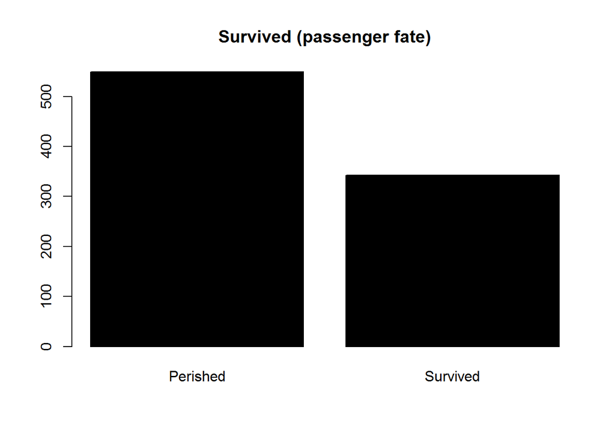

```r
barplot(table(train$Survived),
        names.arg = c("Perished", "Survived"),
        main="Survived (passenger fate)", col="black")
```

##### **Method 2**

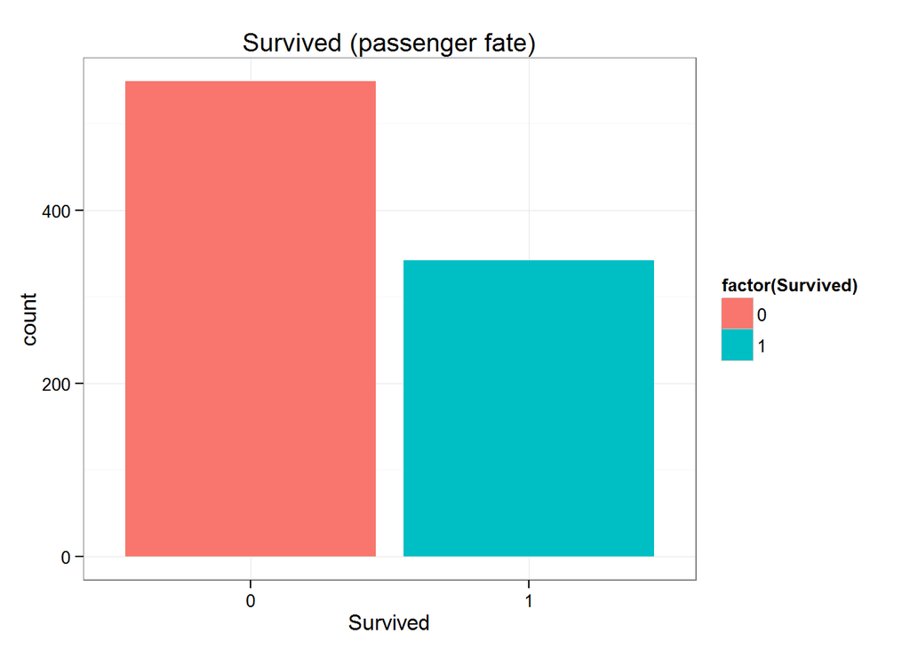

```r
ggplot(data = train, aes(x = factor(Survived), fill = factor(Survived))) +
    geom_bar() +
    ggtitle("Survived (passenger fate)") +
    xlab("Survived") +
    theme_bw()
```

#### **Pclass**

```r
table(train$Pclass)
```

```
##
##   1   2   3
## 216 184 491
```

##### **Method 1**

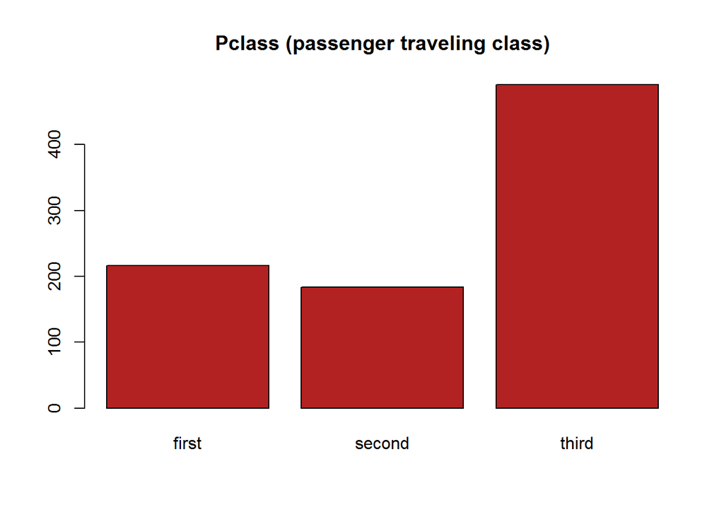

```r
barplot(table(train$Pclass),
        names.arg = c("first", "second", "third"),
        main = "Pclass (passenger traveling class)", col = "firebrick")
```

##### **Method 2**

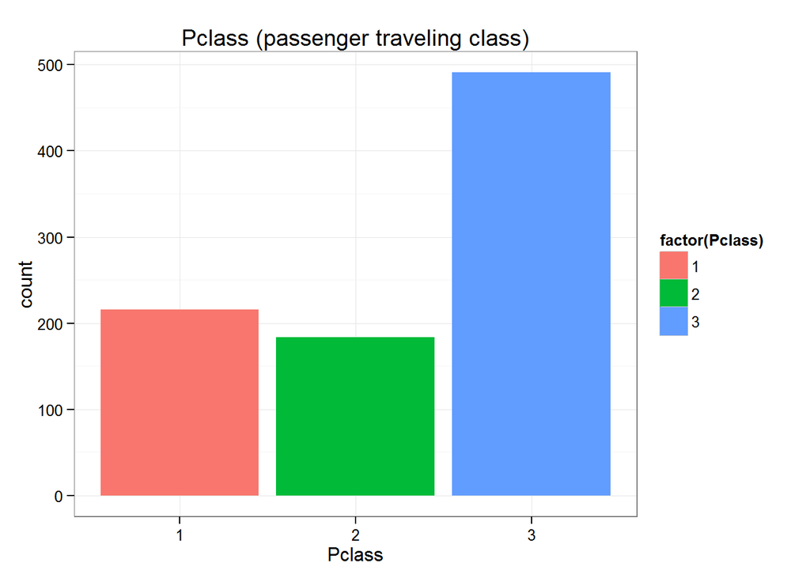

```r
ggplot(data = train, aes(x = factor(Pclass), fill = factor(Pclass))) +
    geom_bar() +
    ggtitle("Pclass (passenger traveling class)") +
    xlab("Pclass") +
    theme_bw()
```

```r
table(train$Survived, train$Pclass)
```

```
##
##       1   2   3
##   0  80  97 372
##   1 136  87 119
```

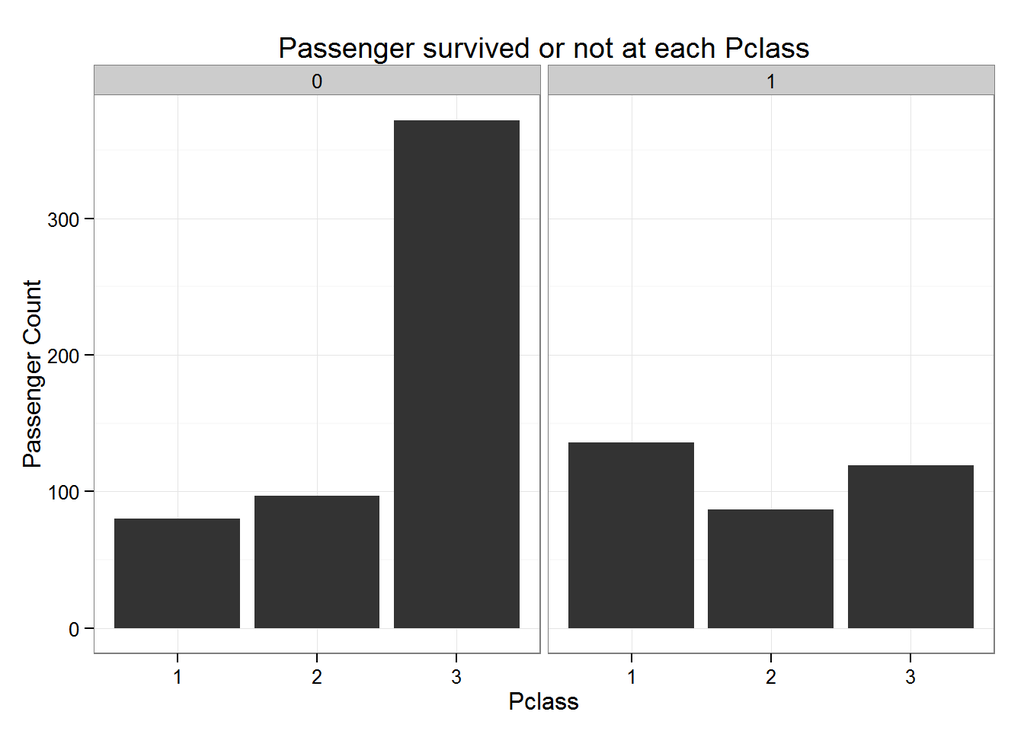

```r
ggplot(data = train, aes(x = factor(Pclass))) +
    geom_bar() +
    facet_grid(. ~ Survived) +
    ggtitle("Passenger survived or not at each Pclass") +
    xlab("Pclass") +
    ylab("Passenger Count") +
    theme_bw()
```

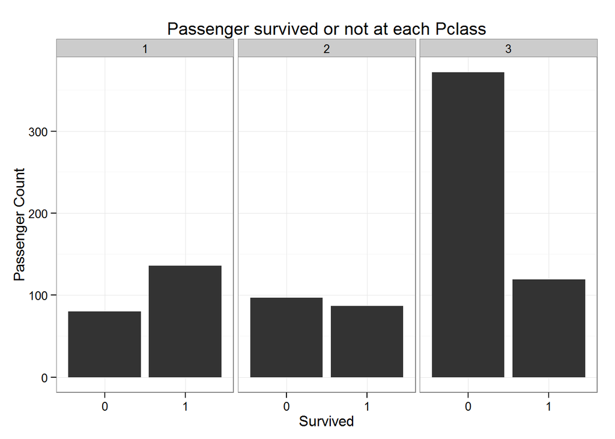

```r
ggplot(data = train, aes(x = factor(Survived))) +
    geom_bar() +
    facet_grid(. ~ Pclass) +
    ggtitle("Passenger survived or not at each Pclass") +
    xlab("Survived") +
    ylab("Passenger Count") +
    theme_bw()
```

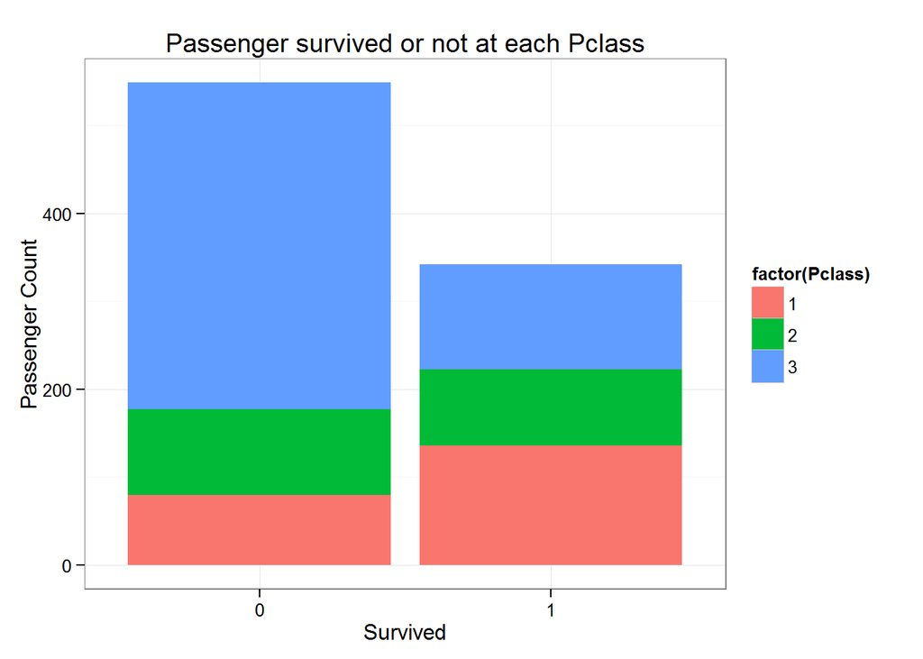

```r
ggplot(data = train, aes(x = factor(Survived), fill = factor(Pclass))) +
    geom_bar() +
    ggtitle("Passenger survived or not at each Pclass") +
    xlab("Survived") +
    ylab("Passenger Count") +
    theme_bw()
```

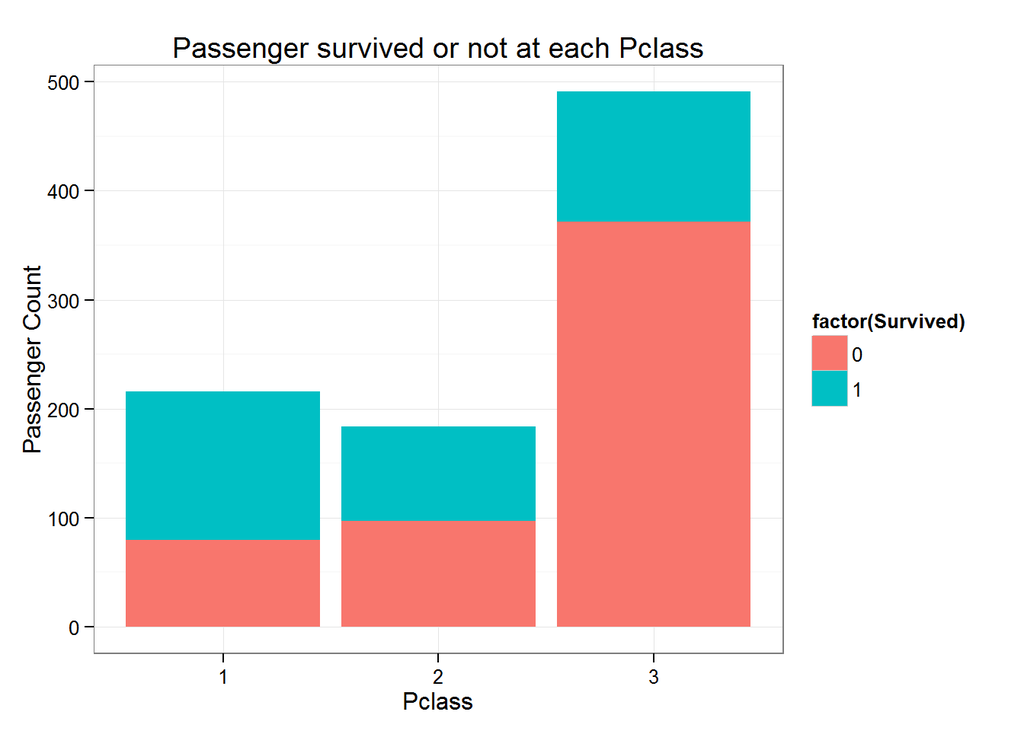

```r
ggplot(data = train, aes(x = factor(Pclass), fill = factor(Survived))) +
    geom_bar() +
    ggtitle("Passenger survived or not at each Pclass") +
    xlab("Pclass") +
    ylab("Passenger Count") +
    theme_bw()
```

#### **Sex**

```r
table(train$Sex)
```

```
##
## female   male
##    314    577
```

##### **Method 1**

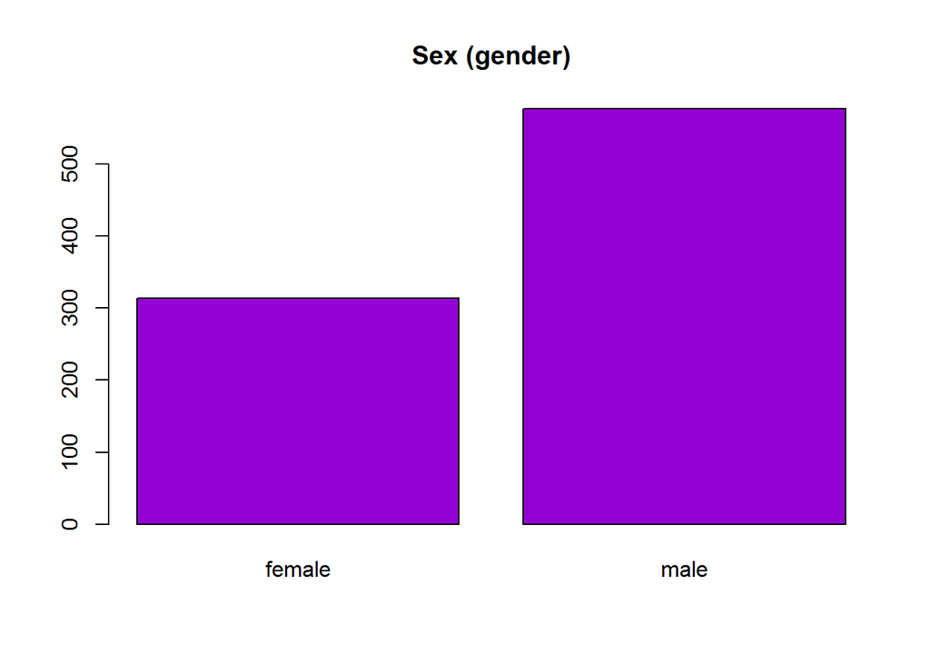

```r
barplot(table(train$Sex), main="Sex (gender)", col="darkviolet")
```

##### **Method 2**

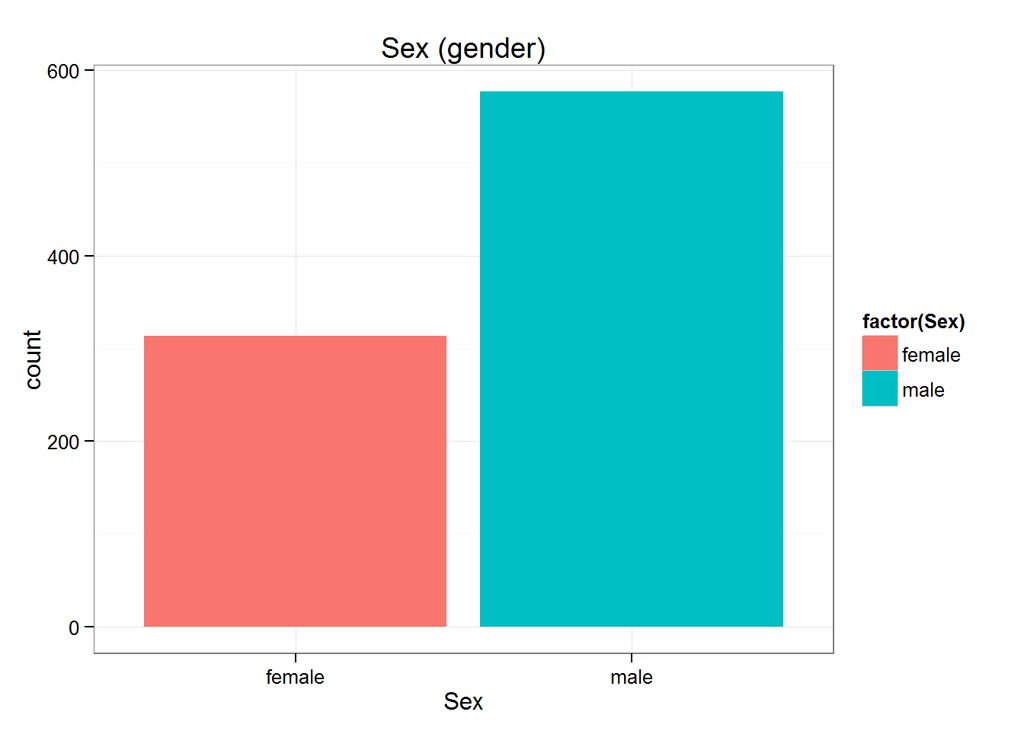

```r
ggplot(data = train, aes(x = factor(Sex), fill = factor(Sex))) +
    geom_bar() +
    ggtitle("Sex (gender)") +
    xlab("Sex") +
    theme_bw()
```

```r
table(train$Survived, train$Sex)
```

```
##
##     female male
##   0     81  468
##   1    233  109
```

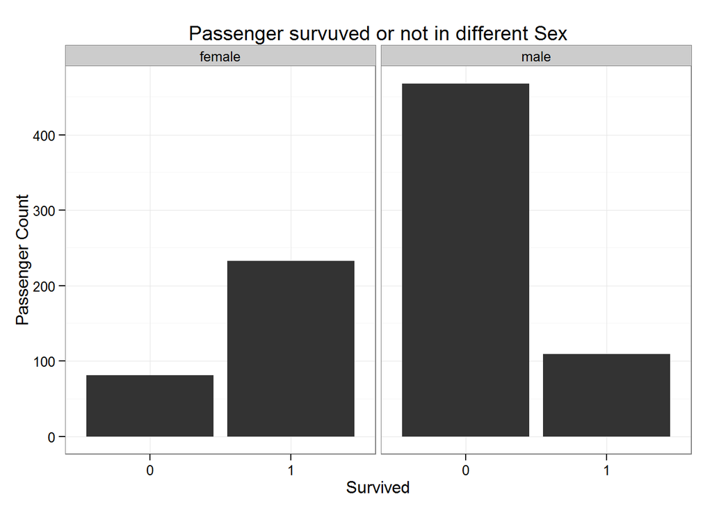

```r
ggplot(data = train, aes(x = factor(Survived))) +
    geom_bar() +
    facet_grid(. ~ Sex) +
    ggtitle("Passenger survuved or not in different Sex") +
    xlab("Survived") +
    ylab("Passenger Count") +
    theme_bw()
```

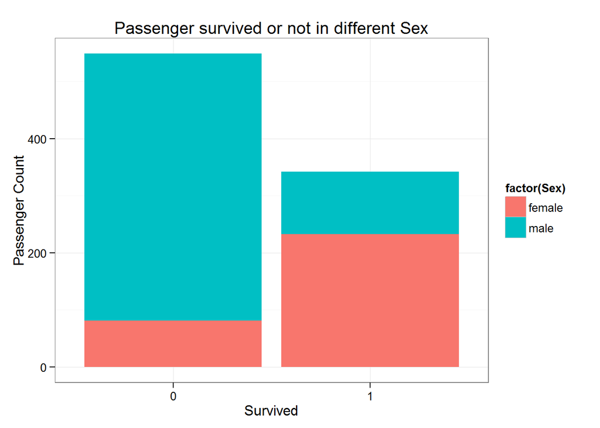

```r
ggplot(data = train, aes(x = factor(Survived), fill = factor(Sex))) +
    geom_bar() +
    ggtitle("Passenger survived or not in different Sex") +
    xlab("Survived") +
    ylab("Passenger Count") +
    theme_bw()
```

#### **Age**

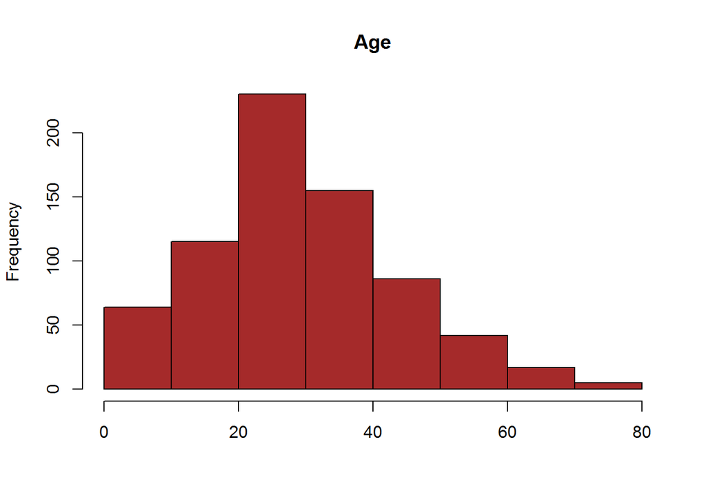

```r
hist(train$Age, main="Age", xlab = NULL, col="brown")
```

```
## stat_bin: binwidth defaulted to range/30. Use 'binwidth = x' to adjust this.
```

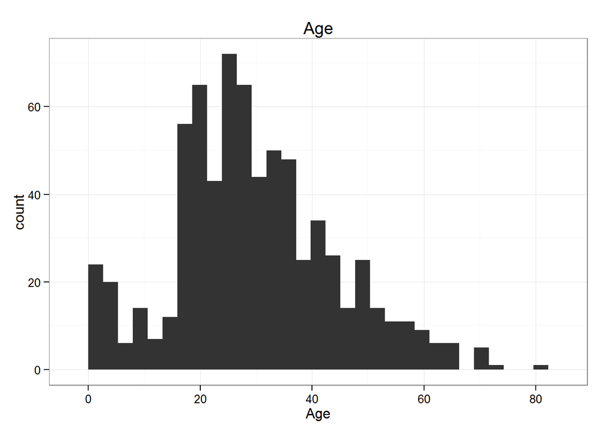

```r
ggplot(data = train, aes(x = Age)) + geom_histogram() + ggtitle("Age") + theme_bw()
```

#### **SibSp**

```r
table(train$SibSp)
```

```
##
##   0   1   2   3   4   5   8
## 608 209  28  16  18   5   7
```

##### **Method 1**

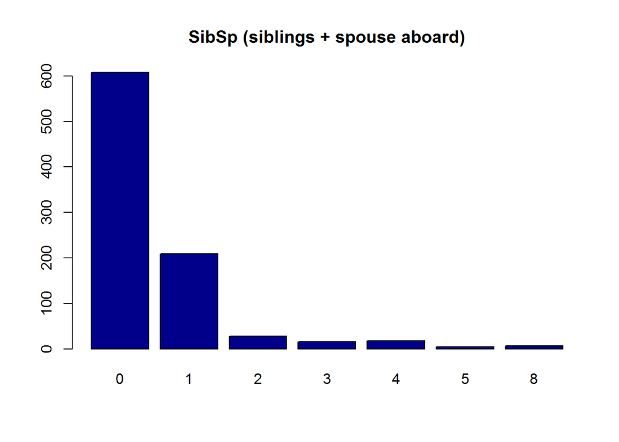

```r
barplot(table(train$SibSp), main="SibSp (siblings + spouse aboard)", col="darkblue")
```

##### **Method 2**

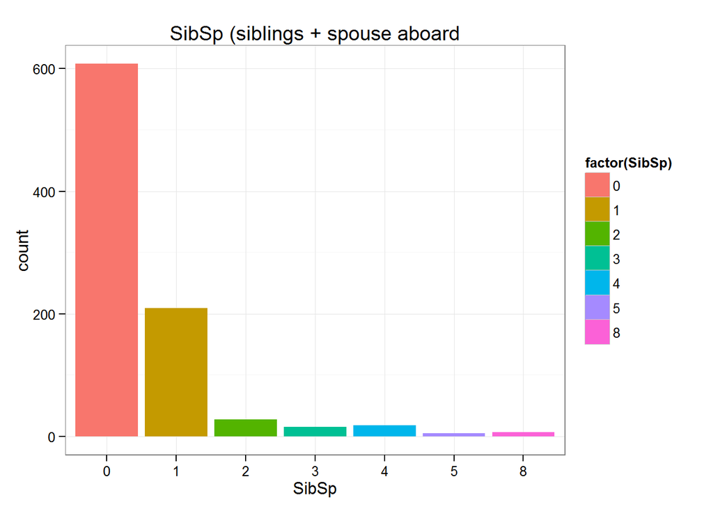

```r
ggplot(data = train, aes(x = factor(SibSp), fill = factor(SibSp))) +
    geom_bar() +
    ggtitle("SibSp (siblings + spouse aboard") +
    xlab("SibSp") +
    theme_bw()
```

```r
table(train$Survived, train$SibSp)
```

```
##
##       0   1   2   3   4   5   8
##   0 398  97  15  12  15   5   7
##   1 210 112  13   4   3   0   0
```

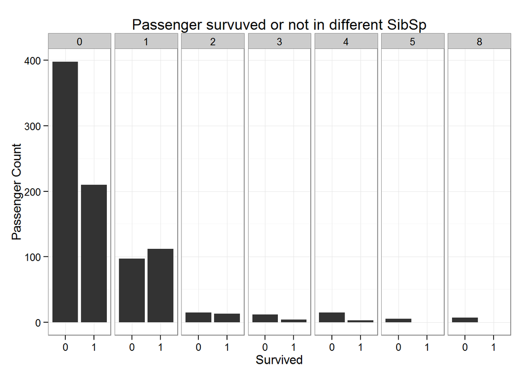

```r
ggplot(data = train, aes(x = factor(Survived))) +
    geom_bar() +
    facet_grid(. ~ SibSp) +
    ggtitle("Passenger survuved or not in different SibSp") +
    xlab("Survived") +
    ylab("Passenger Count") +
    theme_bw()
```

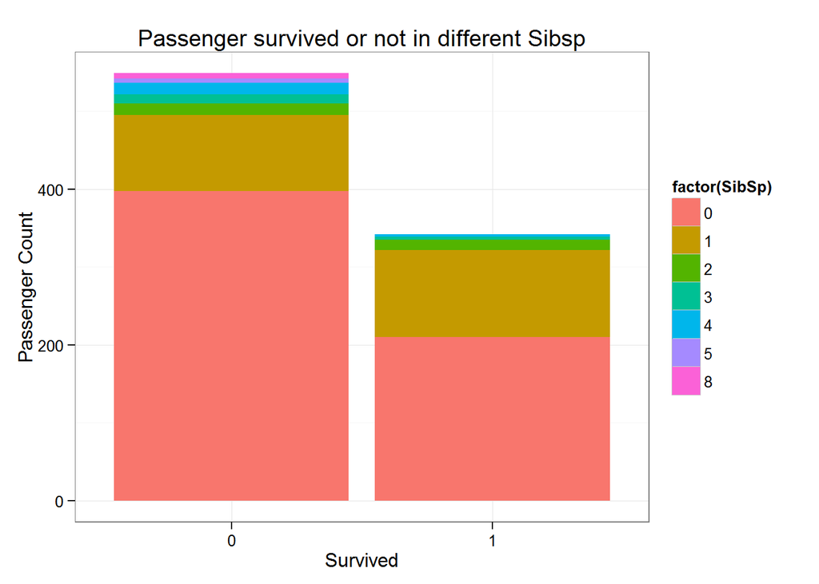

```r
ggplot(data = train, aes(x = factor(Survived), fill = factor(SibSp))) +
    geom_bar() +
    ggtitle("Passenger survived or not in different Sibsp") +
    xlab("Survived") +
    ylab("Passenger Count") +
    theme_bw()
```

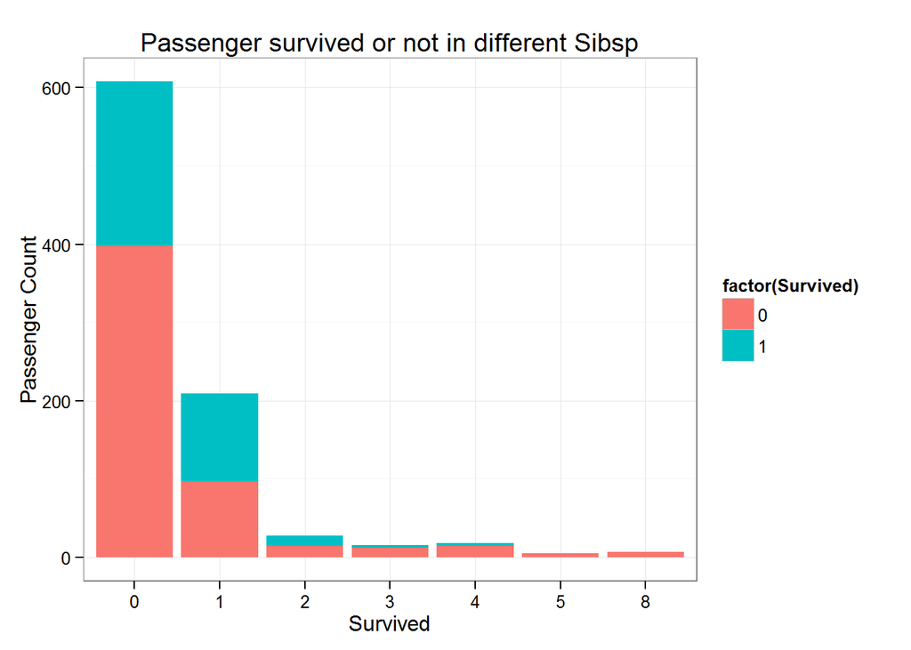

```r
ggplot(data = train, aes(x = factor(SibSp), fill = factor(Survived))) +
    geom_bar() +
    ggtitle("Passenger survived or not in different Sibsp") +
    xlab("Survived") +
    ylab("Passenger Count") +
    theme_bw()
```

#### **Pach**

```r
table(train$Parch)
```

```
##
##   0   1   2   3   4   5   6
## 678 118  80   5   4   5   1
```

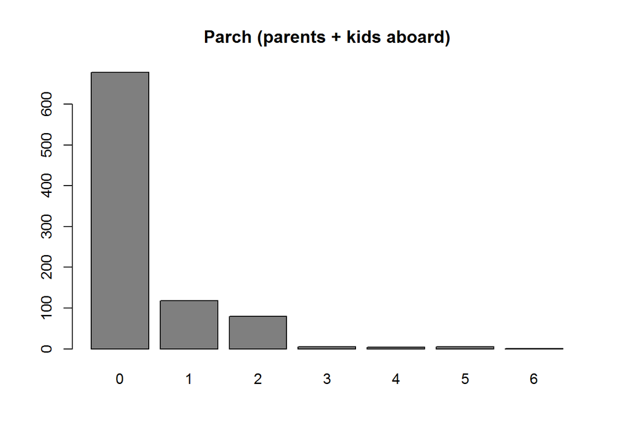

```r
barplot(table(train$Parch), main="Parch (parents + kids aboard)", col="gray50")
```

```r
table(train$Survived, train$Parch)
```

```
##
##       0   1   2   3   4   5   6
##   0 445  53  40   2   4   4   1
##   1 233  65  40   3   0   1   0
```

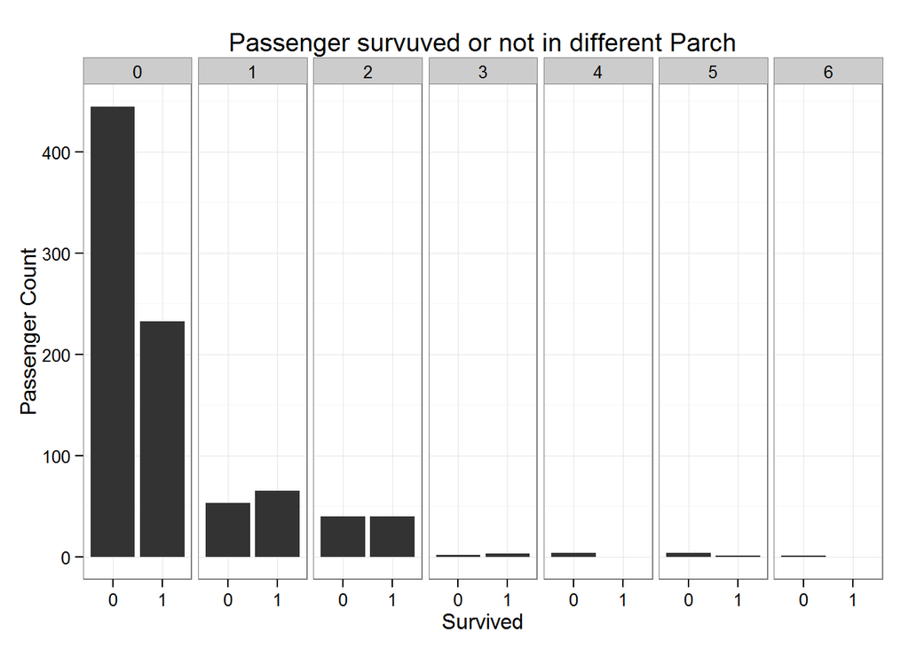

```r
ggplot(data = train, aes(x = factor(Survived))) +
    geom_bar() +
    facet_grid(. ~ Parch) +
    ggtitle("Passenger survuved or not in different Parch") +
    xlab("Survived") +
    ylab("Passenger Count") +
    theme_bw()
```

#### **Fare**

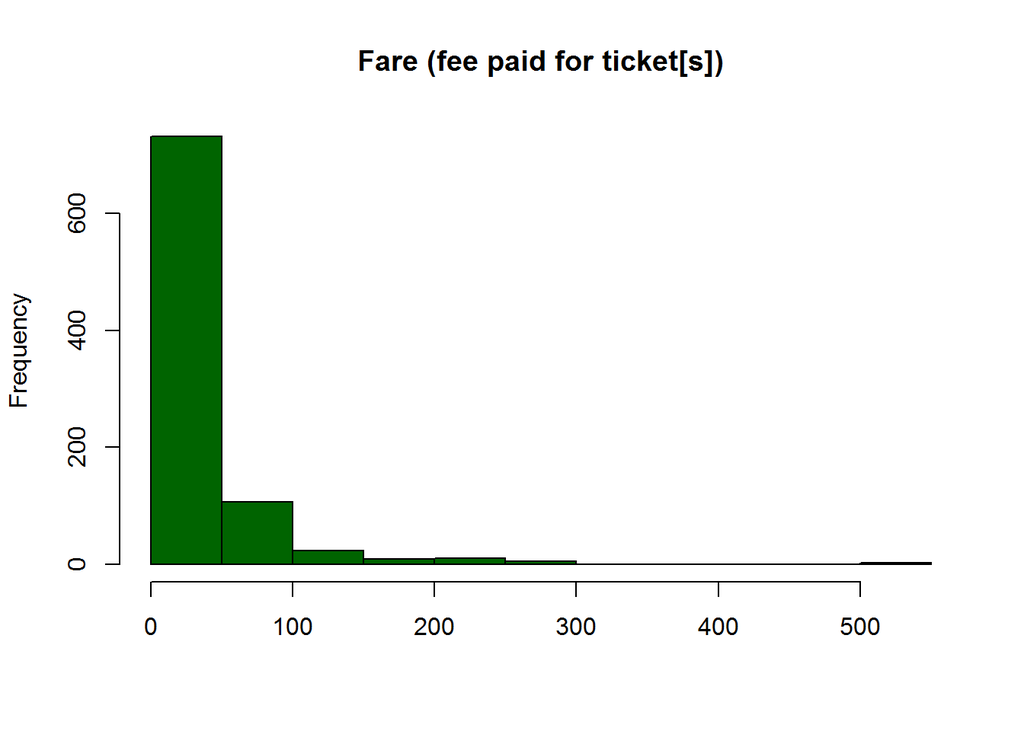

```r
hist(train$Fare, main="Fare (fee paid for ticket[s])", xlab = NULL, col="darkgreen")
```

#### **Embarked**

```r
table(train$Embarked)
```

```
##
##   C   Q   S
## 168  77 644
```

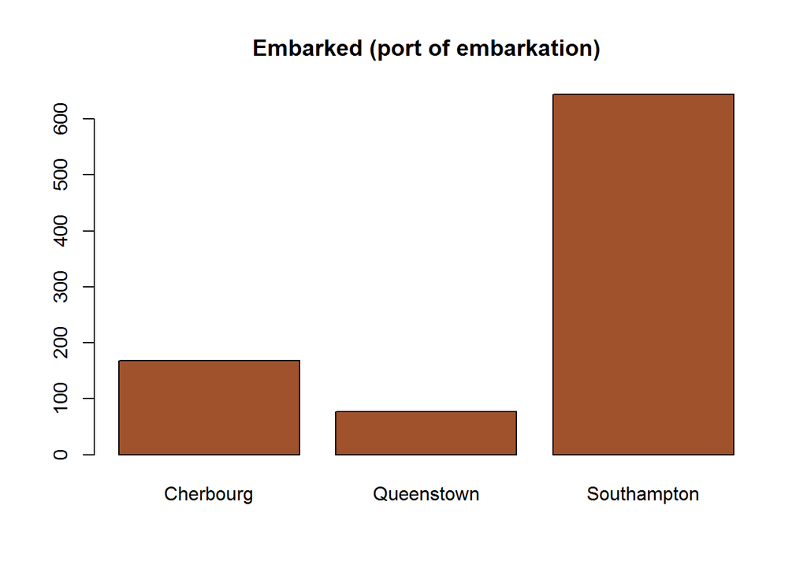

```r
barplot(table(train$Embarked),
        names.arg = c("Cherbourg", "Queenstown", "Southampton"),
        main="Embarked (port of embarkation)", col="sienna")
```

```r
table(train$Survived, train$Embarked)
```

```
##
##       C   Q   S
##   0  75  47 427
##   1  93  30 217
```

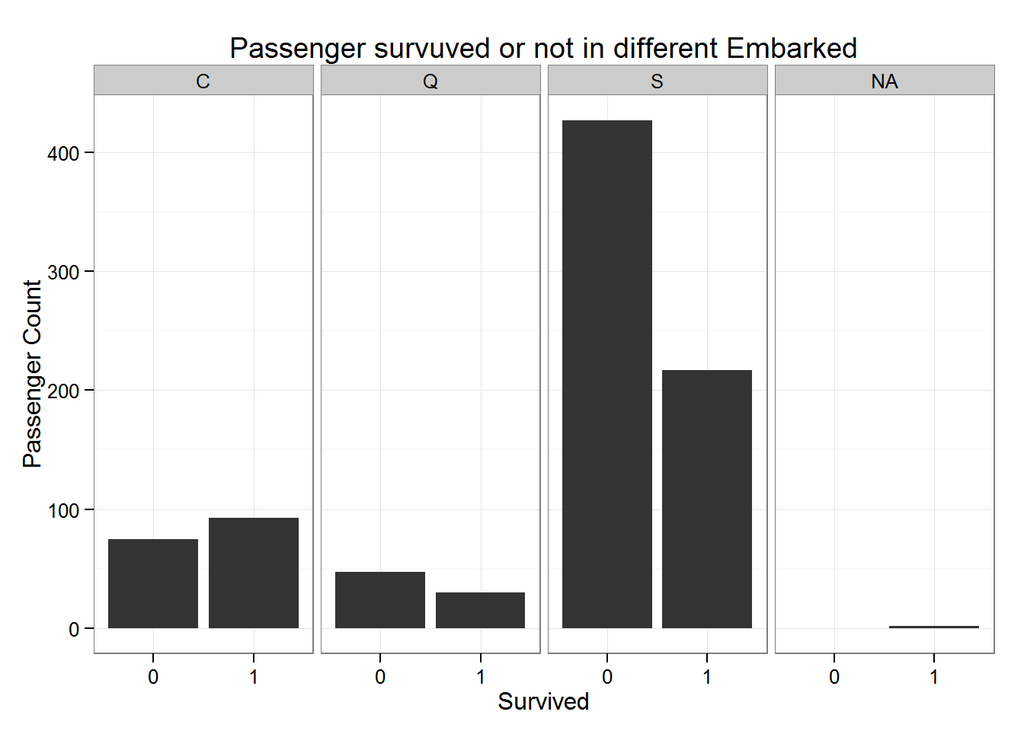

```r
ggplot(data = train, aes(x = factor(Survived))) +
    geom_bar() +
    facet_grid(. ~ Embarked) +
    ggtitle("Passenger survuved or not in different Embarked") +
    xlab("Survived") +
    ylab("Passenger Count") +
    theme_bw()
```

### **(2)缺失值处理**

### Missing variables : **Age**, **Fare**, **Cabin**, **Embarked**

#### **All data, both training and test set:**

```r
test$Survived = NA
all_data = rbind(train, test)
sapply(all_data, function(x) sum(is.na(x)))
```

```
## PassengerId    Survived      Pclass        Name         Sex         Age
##           0         418           0           0           0         263
##       SibSp       Parch      Ticket        Fare       Cabin    Embarked
##           0           0           0           1        1014           2
```

#### **缺失值可视化**

```r
library(Amelia)
```

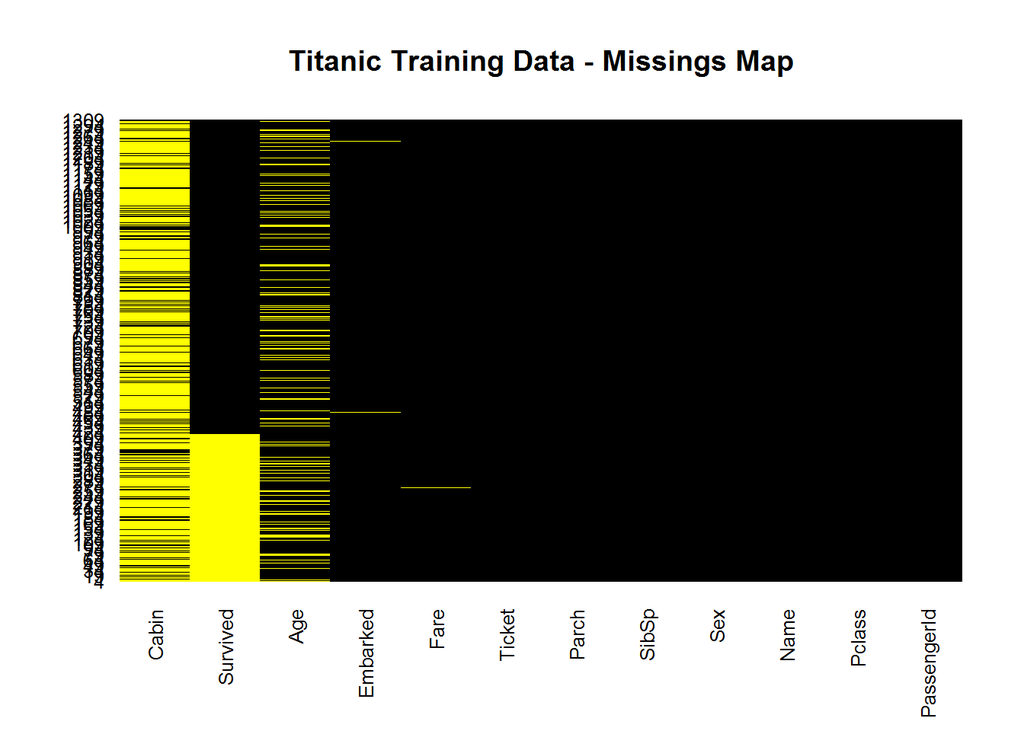

```r
missmap(all_data, main="Titanic Training Data - Missings Map",
        col=c("yellow", "black"), legend=FALSE)
```

#### **Fill in missing Age values:**

```r
library(rpart)
predicted_age <- rpart(Age ~ Pclass + Sex + SibSp + Parch + Fare + Embarked,
                       data = all_data[!is.na(all_data$Age), ], method = "anova")
all_data$Age[is.na(all_data$Age)] <- predict(predicted_age, all_data[is.na(all_data$Age), ])
```

#### **Replace fare value of Passenger on row 1044 with the median fare value:**

```r
all_data$Fare[1044] <- median(all_data$Fare, na.rm = TRUE)
```

#### **Passenger on row 62 and 830 do not have a value for embarkment. Since many passengers embarked at Southampton, give them the value S and code all embarkment codes as factors.**

```r
all_data$Embarked[c(62,830)] = "S"
all_data$Embarked <- factor(all_data$Embarked)
```

#### **Delete the Cabin Name Ticket Varables**

```r
all_data = all_data[, -c(11, 9, 4)]
```

#### **处理缺失值后的数据**

```r
sapply(all_data, function(x) sum(is.na(x)))
```

```
## PassengerId    Survived      Pclass         Sex         Age       SibSp
##           0         418           0           0           0           0
##       Parch        Fare    Embarked
##           0           0           0
```

```r
train = all_data[1:891, ]
test = all_data[892:1309, -2]
dim(train)
```

```
## [1] 891   9
```

```r
dim(test)
```

```
## [1] 418   8
```

### **(3)Create dummary variables**

#### **method 1**

```r
dummies = dummyVars(Survived ~ Pclass + Sex + Age + SibSp + Parch + Fare + Embarked,
                    data = train)
train2 =  predict(dummies, newdata = train)
train2 = as.data.frame(train2)
train2 = cbind(train[, 1:2], train2)
head(train2)
```

```
##   PassengerId Survived Pclass Sex.female Sex.male      Age SibSp Parch
## 1           1        0      3          0        1 22.00000     1     0
## 2           2        1      1          1        0 38.00000     1     0
## 3           3        1      3          1        0 26.00000     0     0
## 4           4        1      1          1        0 35.00000     1     0
## 5           5        0      3          0        1 35.00000     0     0
## 6           6        0      3          0        1 27.43182     0     0
##      Fare Embarked.C Embarked.Q Embarked.S
## 1  7.2500          0          0          1
## 2 71.2833          1          0          0
## 3  7.9250          0          0          1
## 4 53.1000          0          0          1
## 5  8.0500          0          0          1
## 6  8.4583          0          1          0
```

#### **method 2**

```r
dummies = model.matrix(Survived ~ Pclass + Sex + Age + SibSp + Parch + Fare + Embarked, data = train)
train3 = as.data.frame(dummies)
head(train3)
```

```
##   (Intercept) Pclass Sexmale      Age SibSp Parch    Fare EmbarkedQ
## 1           1      3       1 22.00000     1     0  7.2500         0
## 2           1      1       0 38.00000     1     0 71.2833         0
## 3           1      3       0 26.00000     0     0  7.9250         0
## 4           1      1       0 35.00000     1     0 53.1000         0
## 5           1      3       1 35.00000     0     0  8.0500         0
## 6           1      3       1 27.43182     0     0  8.4583         1
##   EmbarkedS
## 1         1
## 2         0
## 3         1
## 4         1
## 5         1
## 6         0
```

### **(4)Split training and testing data set**

#### **Training / testing data set**

```r
set.seed(123)
inTrain = sample(1:2, dim(train)[1], replace = TRUE, prob = c(0.8, 0.2))
training = train[inTrain == 1, ]
testing = train[inTrain == 2, ]
head(training)
```

```
## Source: local data frame [6 x 9]
##
##   PassengerId Survived Pclass    Sex      Age SibSp Parch    Fare Embarked
## 1           1        0      3   male 22.00000     1     0  7.2500        S
## 2           2        1      1 female 38.00000     1     0 71.2833        C
## 3           3        1      3 female 26.00000     0     0  7.9250        S
## 4           6        0      3   male 27.43182     0     0  8.4583        Q
## 5           7        0      1   male 54.00000     0     0 51.8625        S
## 6           9        1      3 female 27.00000     0     2 11.1333        S
```

```r
dim(training)
```

```
## [1] 715   9
```

```r
dim(testing)
```

```
## [1] 176   9
```

```r
set.seed(123)
inTrain = createDataPartition(y = train$Survived, p = 0.8, list = FALSE)
training = train[inTrain, ]
testing = train[-inTrain, ]
head(training)
```

```
## Source: local data frame [6 x 9]
##
##   PassengerId Survived Pclass    Sex      Age SibSp Parch    Fare Embarked
## 1           1        0      3   male 22.00000     1     0  7.2500        S
## 2           4        1      1 female 35.00000     1     0 53.1000        S
## 3           5        0      3   male 35.00000     0     0  8.0500        S
## 4           6        0      3   male 27.43182     0     0  8.4583        Q
## 5           7        0      1   male 54.00000     0     0 51.8625        S
## 6           8        0      3   male  2.00000     3     1 21.0750        S
```

```r
dim(training)
```

```
## [1] 713   9
```

```r
dim(testing)
```

```
## [1] 178   9
```

```r
set.seed(123)
inTrain = sample(1:2, dim(train2)[1], replace = TRUE, prob = c(0.8, 0.2))
training2 = train2[inTrain == 1, ]
testing2 = train2[inTrain == 2, ]
head(training2)
```

```
##   PassengerId Survived Pclass Sex.female Sex.male      Age SibSp Parch
## 1           1        0      3          0        1 22.00000     1     0
## 2           2        1      1          1        0 38.00000     1     0
## 3           3        1      3          1        0 26.00000     0     0
## 6           6        0      3          0        1 27.43182     0     0
## 7           7        0      1          0        1 54.00000     0     0
## 9           9        1      3          1        0 27.00000     0     2
##      Fare Embarked.C Embarked.Q Embarked.S
## 1  7.2500          0          0          1
## 2 71.2833          1          0          0
## 3  7.9250          0          0          1
## 6  8.4583          0          1          0
## 7 51.8625          0          0          1
## 9 11.1333          0          0          1
```

```r
dim(training2)
```

```
## [1] 715  12
```

```r
dim(testing2)
```

```
## [1] 176  12
```

```r
set.seed(123)
inTrain = createDataPartition(y = train2$Survived, p = 0.8, list = FALSE)
training2 = train2[inTrain, ]
testing2 = train2[-inTrain, ]
head(training2)
```

```
##   PassengerId Survived Pclass Sex.female Sex.male      Age SibSp Parch
## 1           1        0      3          0        1 22.00000     1     0
## 4           4        1      1          1        0 35.00000     1     0
## 5           5        0      3          0        1 35.00000     0     0
## 6           6        0      3          0        1 27.43182     0     0
## 7           7        0      1          0        1 54.00000     0     0
## 8           8        0      3          0        1  2.00000     3     1
##      Fare Embarked.C Embarked.Q Embarked.S
## 1  7.2500          0          0          1
## 4 53.1000          0          0          1
## 5  8.0500          0          0          1
## 6  8.4583          0          1          0
## 7 51.8625          0          0          1
## 8 21.0750          0          0          1
```

```r
dim(training2)
```

```
## [1] 713  12
```

```r
dim(testing2)
```

```
## [1] 178  12
```

#### **5-folds CV**

```r
set.seed(123)
folds1 = createFolds(y = train$Survived, k = 5, list = FALSE, returnTrain = TRUE)
table(folds1)
```

```
## folds1
##   1   2   3   4   5
## 178 179 178 178 178
```

```r
sapply(folds1, length)
```

[output not shown]

#### **repeat 5-folds cv**

```r
set.seed(123)
folds2 = createMultiFolds(y = train$Survived, k = 5, times = 3)
sapply(folds2, length)
```

```
## Fold1.Rep1 Fold2.Rep1 Fold3.Rep1 Fold4.Rep1 Fold5.Rep1 Fold1.Rep2
##        713        712        713        713        713        713
## Fold2.Rep2 Fold3.Rep2 Fold4.Rep2 Fold5.Rep2 Fold1.Rep3 Fold2.Rep3
##        713        713        712        713        712        713
## Fold3.Rep3 Fold4.Rep3 Fold5.Rep3
##        713        713        713
```

#### **Bootstrap**

```r
set.seed(123)
resamples = createResample(y = train$Survived, times = 10, list = TRUE)
```